# Capstone_v1_with outlays and stratified

## Classification problem

### About the dataset

This dataset represents a set of possible advertisements on Internet pages. The features encode the geometry of the image (if available) as well as phrases occuring in the URL, the image's URL and alt text, the anchor text, and words occuring near the anchor text.

### Objective

The task is to predict whether an image is an advertisement ("ad") or not ("nonad").

### Attribute Information:

(3 continous; others binary; this is the "STANDARD encoding" mentioned in the [Kushmerick, 99].)

One or more of the three continous features are missing in 28% of the instances; missing values should be interpreted as "unknown".

### Relevant Papers:

N. Kushmerick (1999). "Learning to remove Internet advertisements", 3rd Int Conf Autonomous Agents. Available at www.cs.ucd.ie/staff/nick/research/

### Citation

@misc{Dua:2017 , author = "Dheeru, Dua and Karra Taniskidou, Efi", year = "2017", title = "{UCI} Machine Learning Repository", url = "http://archive.ics.uci.edu/ml", institution = "University of California, Irvine, School of Information and Computer Sciences" }

To see more about data documentation, visit:

https://archive.ics.uci.edu/ml/machine-learning-databases/internet_ads/ad.DOCUMENTATION

```python
import pandas         as     pd
from   urllib.request import urlopen
```

```python
import warnings
import itertools
import numpy as np
import matplotlib.pyplot as plt
import matplotlib.patches as mpatches
import seaborn as sns
warnings.filterwarnings("ignore", category=FutureWarning)
plt.style.use('fivethirtyeight')
import pandas as pd
import matplotlib
import scipy.stats as stats
from math import sqrt
```

```python
from sklearn.preprocessing import StandardScaler
from sklearn.model_selection import train_test_split
from sklearn.dummy import DummyClassifier
from sklearn.linear_model import LogisticRegression
from sklearn.naive_bayes import GaussianNB
from sklearn.tree import DecisionTreeClassifier
from sklearn.svm import SVC
from sklearn.linear_model import SGDClassifier
from sklearn.neighbors import KNeighborsClassifier
from sklearn.ensemble import VotingClassifier, BaggingClassifier
from sklearn.ensemble import RandomForestClassifier, ExtraTreesClassifier
from sklearn.ensemble import AdaBoostClassifier, GradientBoostingClassifier
from xgboost import XGBClassifier
from sklearn.model_selection import cross_val_score
from sklearn import metrics
from sklearn.metrics import confusion_matrix, classification_report, roc_curve, roc_auc_score, log_loss
from sklearn.metrics import f1_score, auc, mean_absolute_error, mean_squared_error, matthews_corrcoef
from sklearn.decomposition import PCA
from sklearn.feature_selection import SelectFromModel, f_regression
from sklearn.utils import resample
from imblearn.over_sampling import SMOTE
```

Get data from the url:

https://archive.ics.uci.edu/ml/machine-learning-databases/internet_ads/

First three features are height,width and aratio which are continuous variables.

Rest are binary variables. Out of which,

- 457 features are from url terms
- 495 features are from origurl terms
- 472 features from ancurl terms
- 111 features from alt terms
- 19 features are from caption terms

Target variable is the last variable in the dataset.

```python
column_names = ['height','width','aratio','local']

###  457 features are from url terms

column_url_names = ['url_images_buttons','url_likesbooks_com','url_www_slake_com',
'url_hydrogeologist','url_oso','url_media','url_peace_images','url_blipverts',
'url_tkaine_kats','url_labyrinth','url_advertising_blipverts','url_images_oso',
'url_area51_corridor','url_ran_gifs','url_express-scripts_com','url_off',
'url_cnet','url_time_1998','url_josefina3','url_truluck_com','url_clawnext_gif',
'url_autopen_com','url_tvgen_com','url_pixs','url_heartland_5309','url_meadows_9196',
'url_blue','url_ad_gif','url_area51','url_www_internauts_ca','url_afn_org',
'url_ran_org','url_shareware_com','url_baons_images','url_area51_labyrinth',
'url_pics','url_image_navigate','url_pool_images','url_carousel_org','url_members_accessus_net',
'url_cmp_flowsoft010','url_smallb_gif','url_www_FlowSoft_com','url_kandinsky',
'url_csuhayward_edu','url_www_yahoo_co_uk','url_ibitexas_com','url_www_haestad_com',
'url_antiwar_com','url_www_monmouth_com','url_infoserver_etl_vt_edu','url_geoguideii_tour',
'url_heartland_pointe','url_romancebooks_pix','url_468x60','url_ads_switchboard_com',
'url_keith_dumble','url_cqi_com','url_images_ixfolder','url_chat_b','url_images_geoguideii',
'url_preferences_com','url_icsi_com','url_pacific_net_sg','url_monmouth_com',
'url_wired_com','url_go2net','url_smiley_gif','url_navigate_b','url_sunsite_unc_edu',
'url_www_pacific_net_sg','url_home_gif','url_library','url_puc_edu',
'url_internauts_ca','url_www_worlddrugstore_com','url_www_ibitexas_com','url_ucsd_edu',
'url_pitcairn_smallb','url_kats','url_cjackson_kandinsky','url_tkaine_rings',
'url_any_time','url_FlowSoft_com','url_geoguideii_nh','url_charlie','url_heartland_meadows',
'url_home_netscape_com','url_9439_butt2','url_catringn_gif','url_martnet',
'url_doubleclick_net','url_lycos_de','url_catringn','url_catring1',
'url_fools_pixs','url_logos','url_private','url_ng_spacedesc','url_larx_com',
'url_site','url_pointe_1154','url_banners','url_pixs_smiley',
'url_www_123greetings_com','url_www_inwap_com','url_cjackson','url_labyrinth_9439',
'url_generated_images','url_image_ng','url_lolnad_private','url_library_pitcairn',
'url_www_mei_co_jp','url_april','url_derived','url_smiley','url_home',
'url_jsd','url_sonic_net','url_send_b','url_website_ora_com','url_pawbutton_gif',
'url_victoria_pharmacy','url_keith','url_pages','url_worlddrugstore_com',
'url_geoguideii_email','url_www_icgnet_com','url_forum','url_www_afn_org',
'url_time','url_www_ran_org','url_main','url_members_keith','url_geoguideii_pages',
'url_banner','url_stinky_gra','url_tkaine_buttons','url_victoria','url_kbell',
'url_www_truluck_com','url_img','url_pics_cats','url_alley','url_claw1',
'url_pharmacy_gif','url_www_autopen_com','url_images_img','url_fbox_vt_edu',
'url_unc_edu','url_ics','url_times','url_forums','url_chat','url_images_go2net_com',
'url_users_aol_com','url_malek','url_jsd_how','url_www_cqi_com','url_advertising_graphics',
'url_pawbutton','url_pictures','url_grouper_com','url_ads_media','url_www_martnet_com',
'url_set_butt','url_how','url_www_wednet_com','url_www_globec_com_au','url_athens',
'url_info','url_www_ireland-today_ie','url_grn_bull','url_sjsu_edu','url_www_antiwar_com',
'url_www_puc_edu','url_sponsor','url_www_news_com','url_flowsoft010','url_memberbanners',
'url_red_ball','url_ads_msn_com','url_icons','url_images','url_access_ch','url_irish_times',
'url_media_images','url_www_adamspharmacy_com','url_geocities_com','url_www_uk_lycos_de',
'url_copymat_com','url_hem1_passagen_se','url_meadows','url_grn','url_gra','url_vt_edu',
'url_www_express-scripts_com','url_imgs','url_personal','url_mindlink_net','url_send',
'url_pages_b','url_accessus_net','url_www_finest_tm_fr','url_geoguideii_search','url_polypkem',
'url_fools','url_www_larx_com','url_marketplace','url_wco_com','url_off_gif','url_tkaine_bars',
'url_icgnet_com','url_www_autotown_com','url_generated','url_9196_pawbutton','url_geoguideii_chat',
'url_www_vrn_de','url_claw1_gif','url_theinternetadvantage_com','url_runofsite','url_romancebooks',
'url_foxy_net','url_francois','url_links','url_athens_forum','url_autotown_com','url_logo',
'url_members','url_auto','url_afn47757','url_gifs','url_esi','url_hollywood','url_forum_8078',
'url_dept','url_adamspharmacy_com','url_valley','url_www_pacificrim_net','url_about',
'url_www_likesbooks_com','url_bossintl_com','url_images_home','url_wednet_com','url_news_com',
'url_arvann_images','url_users','url_netscape_com','url_athens_8774','url_pictures_gc',
'url_butt','url_e_gif','url_sunsetstrip_alley','url_geoguideii_send','url_catring1_gif',
'url_ball_gif','url_bull','url_paul_spu_edu','url_rank','url_2meta_com','url_w_gif',
'url_aol_com','url_lg_gif','url_irish-times_com','url_irish','url_ad_doubleclick_net',
'url_ad_preferences_com','url_bars','url_forums_b','url_gc_icon','url_www_geocities_com',
'url_www_carousel_org','url_ball','url_spu_edu','url_com','url_cnm','url_htm_images',
'url_htm_cmp','url_cmp','url_link_pics','url_mindspring_com','url_geoguideii_logo',
'url_psu_edu','url_go2net_ads','url_www_grouper_com','url_butt2','url_cat','url_www_dreamn_com',
'url_vbtn_gif','url_switchboard_com','url_logo_b','url_assets_images','url_martnet_com',
'url_buttons','url_thejeep_com','url_auto_generated','url_search_b','url_search','url_pharmacy',
'url_assets_auto','url_static_wired_com','url_cats','url_bull_gif','url_memberbanners_live',
'url_pitcairn','url_www_access_ch','url_adv_images','url_navigate','url_runofsite_any',
'url_dejay','url_bishop','url_email_b','url_www_mcs_csuhayward_edu','url_bin','url_paris',
'url_1154_graypaw','url_stinky','url_img_ads','url_bds','url_www_wco_com','url_esi_image',
'url_vrn_de','url_www_toyotaofroswell_com','url_www_copymat_com','url_www_psnw_com',
'url_go2net_com','url_advertising','url_slake_com','url_www_theinternetadvantage_com',
'url_baons','url_geoguideii_rank','url_butt2_gif','url_tkaine','url_art','url_lovisa1',
'url_pool','url_valley_2647','url_any','url_corridor','url_top','url_rank_b',
'url_pacificrim_net','url_image','url_heartland_valley','url_tii','url_123greetings_com',
'url_adv','url_ads','url_hydrogeologist_imgs','url_smallb','url_members_tripod_com',
'url_www_shareware_com','url_images_ads','url_banner_gif','url_vbtn','url_globec_com_au',
'url_www_news-observer_com','url_pointe','url_mandypaul','url_bds_s','url_www_ems_psu_edu',
'url_valley_2539','url_members_aol_com','url_yahoo_co_uk','url_malek_small','url_button',
'url_msn_com','url_graypaw_gif','url_live','url_haestad_com','url_sanjosesabercats_com',
'url_icon_gif','url_april_fools','url_assets','url_set','url_link','url_wc','url_uk',
'url_sj','url_images_set','url_www_bossintl_com','url_nh','url_ng','url_counter','url_lg',
'url_spacedesc','url_bishop_red','url_it','url_ie','url_rings','url_gc','url_peace',
'url_dreamn_com','url_ar','url_ad','url_thumb','url_clawnext','url_dumble','url_kandinsky_t',
'url_email','url_martnet_images','url_uk_gif','url_red','url_geoguideii_forums',
'url_www_2meta_com','url_ran','url_ukonline_co_uk','url_passagen_se','url_psnw_com',
'url_how_htm','url_tm_fr','url_sunsetstrip','url_ora_com','url_logo_gif','url_marketing',
'url_toyotaofroswell_com','url_heartland','url_ixfolder_gif','url_mcet_edu',
'url_enchantedforest','url_alley_6750','url_news-observer_com','url_ireland-today_ie',
'url_times_graphics','url_madamecleo','url_b_gif','url_www_irish-times_com',
'url_tripod_com','url_ad_icons','url_button_gif','url_graypaw','url_excite_com',
'url_web_ukonline_co_uk','url_polypkem_grn','url_gort_ucsd_edu','url_lolnad','url_graphics_ad',
'url_icon','url_falcon_sonic_net','url_picts','url_phoenix_mcet_edu','url_pix_b',
'url_www_icsi_com','url_ixfolder','url_inwap_com','url_www_cob_sjsu_edu','url_pix',
'url_www_thejeep_com','url_tour','url_www_sanjosesabercats_com','url_mei_co_jp',
'url_geoguideii','url_small','url_graphics','url_kbell_charlie','url_zueri_ch','url_arvann']

print(len(column_url_names))
```

```python
###  495 features are from origurl terms

column_origurl_names = ['origurl_labyrinth','origurl_puc_edu','origurl_charlie_charlie',
'origurl_hevern_psychref','origurl_and','origurl_pterry_htm','origurl_bishop',
'origurl_ora_com','origurl_www_nyx_net','origurl_www_yahoo_co_uk','origurl_www_truluck_com',
'origurl_target_wion','origurl_tkaine_sydkat','origurl_meadows_9196','origurl_top',
'origurl_members_xoom_com','origurl_0_rpp','origurl_www_thriveonline_com',
'origurl_adamspharmacy_com','origurl_icsi_com','origurl_tkaine_stvkat','origurl_shareware_com',
'origurl_e_html','origurl_www_123greetings_com','origurl_lofts_7119','origurl_likesbooks_com',
'origurl_gort_ucsd_edu','origurl_users_aol_com','origurl_www_innotts_co_uk','origurl_roll_com',
'origurl_web_ukonline_co_uk','origurl_events','origurl_www_2meta_com','origurl_chuck_html',
'origurl_paris','origurl_chapel','origurl_tii','origurl_how_title','origurl_www_news-observer_com',
'origurl_alley','origurl_april_fools','origurl_carousel','origurl_www_haestad_com',
'origurl_title_html','origurl_lemoyne_edu','origurl_plains_5257','origurl_psychref',
'origurl_jun','origurl_www_interchg_ubc_ca','origurl_ukonline_co_uk','origurl_www_lycos_co_uk',
'origurl_lolnad_private','origurl_ibitexas_com','origurl_wco_com','origurl_jsd',
'origurl_www_rock_n_roll_com','origurl_antiwar_com','origurl_target','origurl_phoenix_mcet_edu',
'origurl_index','origurl_1154_index','origurl_pharmacy','origurl_coltrane','origurl_website_ora_com',
'origurl_index_htm','origurl_dept','origurl_area51_labyrinth','origurl_irish-times_com',
'origurl_mandypaul','origurl_pointe','origurl_plato_htm','origurl_arvann','origurl_wion_0',
'origurl_chapel_safehaven','origurl_worldvillage_com','origurl_nf_htm','origurl_www_martnet_com',
'origurl_hem1_passagen_se','origurl_worlddrugstore_com','origurl_www_globec_com_au',
'origurl_athens_8774','origurl_times_paper','origurl_actup','origurl_inwap',
'origurl_main','origurl_www_larx_com','origurl_dumble_contents','origurl_geocities_com',
'origurl_4301_misfits2','origurl_kattsida','origurl_members_aol_com','origurl_spu_edu',
'origurl_sunsite_unc_edu','origurl_valley_2647','origurl_josefina3','origurl_tkaine',
'origurl_bonchin_cat','origurl_chopin_htm','origurl_punkie','origurl_ubc_ca',
'origurl_links_nf','origurl_misfits2','origurl_area51_vault','origurl_kitty',
'origurl_plato','origurl_hollywood_7735','origurl_link','origurl_www_monmouth_com',
'origurl_hist','origurl_members_tripod_com','origurl_www_ibitexas_com',
'origurl_cgidir_dll','origurl_heartland','origurl_pages_catscats','origurl_tkaine_linda',
'origurl_crawler','origurl_paul_spu_edu','origurl_bishop_pterry','origurl_carousel_org',
'origurl_romance','origurl_nyx_net','origurl_hollywood','origurl_simonc','origurl_sox',
'origurl_www_cob_sjsu_edu','origurl_timeout_5','origurl_leonora','origurl_fh-rpl_de',
'origurl_vt_edu','origurl_ucsd_edu','origurl_www_carousel_org','origurl_www_antiwar_com',
'origurl_FlowSoft_com','origurl_kbell_charlie','origurl_www_likesbooks_com','origurl_labyrinth_9439',
'origurl_www_icsi_com','origurl_events_aprilfoolsday','origurl_tii_tii','origurl_athens_forum',
'origurl_library','origurl_valley','origurl_ics_ikenobo','origurl_unc_edu','origurl_kandin',
'origurl_bordeaux','origurl_charlie','origurl_6750_paws','origurl_cccats','origurl_linda_htm',
'origurl_2647_coltrane','origurl_vault_3440','origurl_victoria_pharmacy','origurl_wv',
'origurl_kandin_html','origurl_soho_lofts','origurl_sunsetstrip_alley','origurl_slake_com',
'origurl_autotown_com','origurl_www_sanjosesabercats_com','origurl_infoserver_etl_vt_edu',
'origurl_kushmerick','origurl_www_toyotaofroswell_com','origurl_turbo','origurl_sw','origurl_hills',
'origurl_st','origurl_mogwhi','origurl_sj','origurl_pointe_1154','origurl_monmouth_com','origurl_mei_co_jp',
'origurl_sonic_net','origurl_safehaven_index','origurl_simonc_cybermog','origurl_messier',
'origurl_cybercats','origurl_search','origurl_heartland_5309','origurl_psnw_com','origurl_keith_dumble',
'origurl_links','origurl_nav','origurl_nf','origurl_sunsetstrip','origurl_kandinsky','origurl_meadows_3727',
'origurl_www_afn_org','origurl_southbeach','origurl_pacific_net_sg','origurl_heartland_pointe',
'origurl_valley_2539','origurl_catscats_html','origurl_horn_html','origurl_area51','origurl_pages',
'origurl_chopin','origurl_it','origurl_bonchin','origurl_www_worldvillage_com','origurl_00_html',
'origurl_vrn_de','origurl_home_netscape_com','origurl_simstory_html','origurl_biopic_htm',
'origurl_dll','origurl_cmeese_malibu','origurl_ics','origurl_linda','origurl_fr','origurl_private_biopic',
'origurl_corridor_4590','origurl_leonora_html','origurl_dejay','origurl_aprilfoolsday','origurl_fools',
'origurl_biopic','origurl_lofts','origurl_heartland_plains','origurl_passagen_se','origurl_djang',
'origurl_5257_timstory','origurl_5_hpe','origurl_cybermog_htm','origurl_area51_corridor','origurl_yosemite_4301',
'origurl_wosc_html','origurl_rpp','origurl_personal','origurl_express-scripts_com','origurl_madamecleo',
'origurl_malibu','origurl_sjsu_edu','origurl_news','origurl_www_ems_psu_edu','origurl_7735_mcp',
'origurl_sox_htm','origurl_mcet_edu','origurl_punkie_htm','origurl_midnite','origurl_foxy_net',
'origurl_maple_lemoyne_edu','origurl_times','origurl_news_com','origurl_4010_index','origurl_www_slake_com',
'origurl_larx_com','origurl_www_FlowSoft_com','origurl_paper','origurl_members_keith','origurl_paper_1998',
'origurl_inwap_com','origurl_www_tkz_fh-rpl_de','origurl_members_accessus_net','origurl_kattsida_html',
'origurl_cjackson_kandinsky','origurl_main_htm','origurl_www_mei_co_jp','origurl_www_adamspharmacy_com',
'origurl_20_timeout','origurl_corridor_5139','origurl_falcon_sonic_net','origurl_lycos_co_uk',
'origurl_ran','origurl_afn47757_midnite','origurl_www_vrn_de','origurl_5309_index','origurl_stvkat_htm',
'origurl_hpe','origurl_wv_square','origurl_keith','origurl_www_pacificrim_net','origurl_how',
'origurl_www_metacrawler_com','origurl_pacificrim_net','origurl_5257_simstory','origurl_cmeese',
'origurl_metacrawler_com','origurl_catscats','origurl_wosc','origurl_xoom_com','origurl_innotts_co_uk',
'origurl_paris_3963','origurl_general_kushmerick','origurl_mindlink_net','origurl_cybermog',
'origurl_kerouac_htm','origurl_internauts_ca','origurl_mcp','origurl_martnet_com','origurl_toyotaofroswell_com',
'origurl_msheryl','origurl_vault','origurl_malibu_html','origurl_jsd_how','origurl_polypkem_index',
'origurl_corridor','origurl_zoe_html','origurl_afn_org','origurl_theinternetadvantage_com','origurl_coltrane_htm',
'origurl_timeout','origurl_8078_home','origurl_turbo_html','origurl_heartland_meadows','origurl_news-observer_com',
'origurl_www_psnw_com','origurl_contents_html','origurl_tkaine_mogwhi','origurl_stanford_edu','origurl_www_bossintl_com',
'origurl_general','origurl_switchboard_com','origurl_cgidir','origurl_access_ch','origurl_sydkat_htm',
'origurl_hotsprings','origurl_baons','origurl_peace','origurl_2647_chopin','origurl_www_worlddrugstore_com',
'origurl_actup_index','origurl_bin_cgidir','origurl_www_internauts_ca','origurl_library_pitcairn','origurl_inwap_cats',
'origurl_lolnad','origurl_pterry','origurl_lovisa1','origurl_www_dreamn_com','origurl_polypkem','origurl_tm_fr',
'origurl_athens','origurl_copymat_com','origurl_soho','origurl_victoria','origurl_bossintl_com','origurl_westhollywood',
'origurl_private','origurl_cat','origurl_cats_htm','origurl_malek_kandin','origurl_yosemite','origurl_www_inwap_com',
'origurl_afn47757_plato','origurl_timstory','origurl_excite_com','origurl_forum_8078','origurl_cats',
'origurl_kitty_and','origurl_dreamn_com','origurl_irish_times','origurl_crawler_general','origurl_bordeaux_actup',
'origurl_hotsprings_4527','origurl_kbell','origurl_stinky_cats','origurl_plains','origurl_netscape_com',
'origurl_csuhayward_edu','origurl_safehaven','origurl_tripod_com','origurl_alley_6750','origurl_sanjosesabercats_com',
'origurl_www_news_com','origurl_mogwhi_htm','origurl_www_theinternetadvantage_com','origurl_thejeep_com',
'origurl_3963_leonora','origurl_www_wednet_com','origurl_autopen_com','origurl_charlie_html',
'origurl_forum','origurl_kaitlin','origurl_april','origurl_grouper_com','origurl_www_ran_org',
'origurl_sydkat','origurl_heartland_6712','origurl_rpp_20','origurl_2647_kaitlin','origurl_psychref_html',
'origurl_josefina3_horn','origurl_malek','origurl_stvkat','origurl_timstory_html','origurl_corp',
'origurl_story','origurl_thriveonline_com','origurl_bds_punkie','origurl_zoe','origurl_kerouac',
'origurl_123greetings_com','origurl_2647_kerouac','origurl_www_access_ch','origurl_www_express-scripts_com',
'origurl_paws','origurl_wednet_com','origurl_francois','origurl_zdnet_com','origurl_simstory',
'origurl_www_puc_edu','origurl_www_irish-times_com','origurl_www_copymat_com','origurl_cjackson',
'origurl_kaitlin_htm','origurl_tori_html','origurl_southbeach_7597','origurl_home_html','origurl_hpe_10',
'origurl_pad_htm','origurl_psu_edu','origurl_www_shareware_com','origurl_bin','origurl_arvann_pages',
'origurl_tori','origurl_dumble','origurl_www_icgnet_com','origurl_romancebooks','origurl_3727_turbo',
'origurl_football','origurl_msheryl_djang','origurl_zueri_ch','origurl_aol_com','origurl_bds',
'origurl_cat_html','origurl_and_tori','origurl_hollywood_9662','origurl_djang_html','origurl_yahoo_co_uk',
'origurl_truluck_com','origurl_shtml','origurl_link_chuck','origurl_members','origurl_www_thejeep_com',
'origurl_2meta_com','origurl_cats_html','origurl_www_autopen_com','origurl_hevern','origurl_ikenobo',
'origurl_accessus_net','origurl_www_wco_com','origurl_contents','origurl_pitcairn','origurl_westhollywood_4010',
'origurl_messier_html','origurl_icgnet_com','origurl_mandypaul_main','origurl_links_carousel','origurl_square_chapel',
'origurl_www_grouper_com','origurl_6712_cats','origurl_www_MeissnerChevrolet_autotown_com','origurl_globec_com_au',
'origurl_meadows','origurl_afn47757','origurl_www_geocities_com','origurl_haestad_com','origurl_midnite_htm',
'origurl_tkaine_sox','origurl_lovisa1_kattsida','origurl_fr_bordeaux','origurl_mindspring_com','origurl_7597_kitty',
'origurl_wired_com','origurl_paws_pad','origurl_irish','origurl_square','origurl_pad','origurl_method',
'origurl_www_mcs_csuhayward_edu','origurl_www_pacific_net_sg','origurl_chuck','origurl_ran_org',
'origurl_misfits2_htm','origurl_stinky','origurl_horn','origurl_heartland_valley','origurl_heartland_hills',
'origurl_www_finest_tm_fr','origurl_carousel_links','origurl_kushmerick_method','origurl_txt',
'origurl_method_0','origurl_title','origurl_fbox_vt_edu','origurl_index_html','origurl_asp','origurl_mcp_htm',
'origurl_home','origurl_netcenter','origurl_hydrogeologist','origurl_2539_index','origurl_teams','origurl_wion']

print(len(column_origurl_names))
```

```python
### Create  472 features from ancurl terms
column_ancurl_names = ['ancurl_search_direct','ancurl_likesbooks_com','ancurl_mirror','ancurl_www_slake_com',
'ancurl_cnet_cat','ancurl_hydrogeologist','ancurl_geoguide','ancurl_2fcrawler','ancurl_clawring_htm',
'ancurl_tkaine_kats','ancurl_labyrinth','ancurl_clickthru_clickid','ancurl_redirect','ancurl_com_ads',
'ancurl_area51_corridor','ancurl_express-scripts_com','ancurl_cnet','ancurl_time_1998','ancurl_josefina3',
'ancurl_truluck_com','ancurl_cgiadman','ancurl_linkpg_htm','ancurl_geoguide_rank','ancurl_area51',
'ancurl_www_internauts_ca','ancurl_afn_org','ancurl_www_microsoft_com','ancurl_nph','ancurl_ran_org',
'ancurl_comprod_mirror','ancurl_shareware_com','ancurl_jump','ancurl_area51_labyrinth','ancurl_pics',
'ancurl_nsads_hotwired_com','ancurl_new','ancurl_net','ancurl_relocate_ad','ancurl_sendform','ancurl_carousel_org',
'ancurl_members_accessus_net','ancurl_home_htm','ancurl_index_html','ancurl_www_FlowSoft_com','ancurl_kandinsky',
'ancurl_csuhayward_edu','ancurl_www_yahoo_co_uk','ancurl_ibitexas_com','ancurl_www_monmouth_com',
'ancurl_infoserver_etl_vt_edu','ancurl_heartland_pointe','ancurl_msn','ancurl_468x60','ancurl_bin_click',
'ancurl_general','ancurl_keith_dumble','ancurl_cqi_com','ancurl_heartland_plains','ancurl_redir',
'ancurl_webring_org','ancurl_uk_sv','ancurl_mem','ancurl_next','ancurl_pacific_net_sg','ancurl_monmouth_com',
'ancurl_news','ancurl_adclick','ancurl_default','ancurl_exe_cid','ancurl_claw','ancurl_bin_webring',
'ancurl_emailbox','ancurl_sunsite_unc_edu','ancurl_exec_obidos','ancurl_obidos','ancurl_www_pacific_net_sg',
'ancurl_library','ancurl_puc_edu','ancurl_internauts_ca','ancurl_n_a','ancurl_www_ibitexas_com',
'ancurl_ucsd_edu','ancurl_kats','ancurl_cjackson_kandinsky','ancurl_clickid','ancurl_any_time',
'ancurl_1_cid','ancurl_ring','ancurl_FlowSoft_com','ancurl_nph_adclick','ancurl_adclick_exe',
'ancurl_event','ancurl_general_site','ancurl_2fclick','ancurl_home_netscape_com','ancurl_bin_homestead',
'ancurl_click_runid','ancurl_martnet','ancurl_doubleclick_net','ancurl_st_uk','ancurl_catring_html',
'ancurl_ng_spacedesc','ancurl_familyid','ancurl_yahoo','ancurl_site','ancurl_redirect_dll','ancurl_pointe_1154',
'ancurl_home_html','ancurl_www_123greetings_com','ancurl_cat_general','ancurl_www_inwap_com','ancurl_cjackson',
'ancurl_labyrinth_9439','ancurl_library_pitcairn','ancurl_www_mei_co_jp','ancurl_april','ancurl_comprod',
'ancurl_ukie','ancurl_home','ancurl_www_lycos_co_uk','ancurl_jsd','ancurl_ans_entry','ancurl_keith',
'ancurl_www_icgnet_com','ancurl_forum','ancurl_redirect_cgi','ancurl_www_afn_org','ancurl_geoguide_emailme',
'ancurl_time','ancurl_www_ran_org','ancurl_main','ancurl_members_keith','ancurl_http_ad','ancurl_2f_2fwww',
'ancurl_ad_bin','ancurl_www_amazon_com','ancurl_4_mem','ancurl_www_truluck_com','ancurl_bridalinfo',
'ancurl_pics_cats','ancurl_direct','ancurl_image_http','ancurl_fbox_vt_edu','ancurl_unc_edu',
'ancurl_d_ukie','ancurl_forums','ancurl_co_uk','ancurl_e_html','ancurl_inwap_cats','ancurl_malek',
'ancurl_jsd_how','ancurl_www_cqi_com','ancurl_redirect_http','ancurl_name','ancurl_1_d','ancurl_kat001',
'ancurl_magic_adclick','ancurl_grouper_com','ancurl_readersndex_com','ancurl_excite_468x60','ancurl_click_ng',
'ancurl_www_martnet_com','ancurl_http_2f','ancurl_direct_topic','ancurl_how','ancurl_www_wednet_com',
'ancurl_www_globec_com_au','ancurl_athens','ancurl_info','ancurl_schwab','ancurl_sjsu_edu','ancurl_www_puc_edu',
'ancurl_a_uk','ancurl_www_news_com','ancurl_2fclick_ng','ancurl_ads_msn_com','ancurl_images','ancurl_access_ch',
'ancurl_home_ring','ancurl_plug_go2net_com','ancurl_geocities_com','ancurl_geoguide_tour','ancurl_copymat_com',
'ancurl_www_webring_org','ancurl_groupid_1','ancurl_gif_pk','ancurl_dll_cid','ancurl_adid','ancurl_vt_edu',
'ancurl_worlddrug_com','ancurl_edition','ancurl_www_express-scripts_com','ancurl_personal','ancurl_gid',
'ancurl_bin_geoguide','ancurl_mindlink_net','ancurl_accessus_net','ancurl_type','ancurl_ng_type','ancurl_polypkem',
'ancurl_fools','ancurl_bin_cgiadman','ancurl_marketplace','ancurl_wco_com','ancurl_links_html','ancurl_tkaine_bars',
'ancurl_icgnet_com','ancurl_www_autotown_com','ancurl_adcount_plx','ancurl_1_familyid','ancurl_yahoo_com',
'ancurl_page','ancurl_theinternetadvantage_com','ancurl_runofsite','ancurl_romancebooks','ancurl_francois',
'ancurl_links','ancurl_athens_forum','ancurl_site_sw','ancurl_autotown_com','ancurl_amazon_com',
'ancurl_site_ne','ancurl_qual','ancurl_members','ancurl_exe','ancurl_pratchett','ancurl_afn47757',
'ancurl_esi','ancurl_1154_linkpg','ancurl_desc','ancurl_forum_8078','ancurl_topic','ancurl_bin_acc',
'ancurl_valley','ancurl_delv','ancurl_family','ancurl_lspace_org','ancurl_www_pacificrim_net','ancurl_about',
'ancurl_webring_ring','ancurl_www_likesbooks_com','ancurl_bossintl_com','ancurl_runid','ancurl_wednet_com',
'ancurl_news_com','ancurl_lycos_co_uk','ancurl_arvann_images','ancurl_526_redirect','ancurl_ads_msn',
'ancurl_netscape_com','ancurl_athens_8774','ancurl_click_profileid','ancurl_qual_mc','ancurl_homestead_ans',
'ancurl_paul_spu_edu','ancurl_dll','ancurl_readersndex','ancurl_dir','ancurl_rank','ancurl_2meta_com',
'ancurl_Lpage_com','ancurl_emailme','ancurl_event_ng','ancurl_3a_2fcrawler','ancurl_cgiadman_dll',
'ancurl_aol_com','ancurl_lg_gif','ancurl_magic','ancurl_bin_ad','ancurl_www_worlddrug_com','ancurl_ring_midnight',
'ancurl_irish-times_com','ancurl_download','ancurl_http_www','ancurl_homepage','ancurl_midnight_id',
'ancurl_ad_doubleclick_net','ancurl_exec','ancurl_mem_1','ancurl_msn_com','ancurl_preferences',
'ancurl_contact','ancurl_bars','ancurl_products','ancurl_www_geocities_com','ancurl_www_carousel_org',
'ancurl_spu_edu','ancurl_com','ancurl_cnm','ancurl_webring_home','ancurl_link_pics','ancurl_cid',
'ancurl_psu_edu','ancurl_ads_redirect','ancurl_cfm','ancurl_www_grouper_com','ancurl_member',
'ancurl_index','ancurl_cat','ancurl_www_dreamn_com','ancurl_afn47757_clawring','ancurl_switchboard_com',
'ancurl_ad_preferences','ancurl_inwap','ancurl_adcount','ancurl_martnet_com','ancurl_thejeep_com',
'ancurl_search','ancurl_shtml','ancurl_www_yahoo','ancurl_desc_4','ancurl_cats','ancurl_pitcairn',
'ancurl_www_access_ch','ancurl_runofsite_any','ancurl_url','ancurl_dejay','ancurl_gallery',
'ancurl_bishop','ancurl_features_forums','ancurl_area','ancurl_www_mcs_csuhayward_edu',
'ancurl_bin','ancurl_bds','ancurl_www_wco_com','ancurl_www_toyotaofroswell_com','ancurl_www_copymat_com',
'ancurl_go2net_com','ancurl_delv_dir','ancurl_slake_com','ancurl_www_readersndex','ancurl_www_theinternetadvantage_com',
'ancurl_edition_cnet','ancurl_tkaine','ancurl_catring','ancurl_asp','ancurl_art','ancurl_relocate',
'ancurl_468x60_runofsite','ancurl_valley_2647','ancurl_any','ancurl_ans','ancurl_corridor','ancurl_amp',
'ancurl_top','ancurl_pacificrim_net','ancurl_image','ancurl_heartland_valley','ancurl_tii',
'ancurl_123greetings_com','ancurl_ads','ancurl_www_yahoo_com','ancurl_cuteftp','ancurl_acc',
'ancurl_bin_search','ancurl_www_shareware_com','ancurl_dir_qual','ancurl_globec_com_au','ancurl_www_news-observer_com',
'ancurl_index_htm','ancurl_xmission_com','ancurl_ukie_s','ancurl_629_redirect','ancurl_pointe',
'ancurl_www_ems_psu_edu','ancurl_http_ads','ancurl_members_aol_com','ancurl_www_xmission_com',
'ancurl_yahoo_co_uk','ancurl_ring_kat001','ancurl_msn_com','ancurl_groupid','ancurl_geoguide_geoguide',
'ancurl_sanjosesabercats_com','ancurl_excite','ancurl_april_fools','ancurl_slagen','ancurl_link',
'ancurl_tour_member','ancurl_uk','ancurl_people','ancurl_sw','ancurl_sv','ancurl_st','ancurl_sj',
'ancurl_pl','ancurl_pk','ancurl_www_bossintl_com','ancurl_ng','ancurl_ne','ancurl_mc',
'ancurl_lg','ancurl_spacedesc','ancurl_it','ancurl_ie','ancurl_id','ancurl_go','ancurl_gg',
'ancurl_homestead','ancurl_bin_nph','ancurl_peace','ancurl_t_s','ancurl_de','ancurl_co',
'ancurl_dreamn_com','ancurl_plx_http','ancurl_ad','ancurl_rnd','ancurl_dumble','ancurl_kandinsky_p',
'ancurl_linkpg','ancurl_webring','ancurl_ref','ancurl_www_2meta_com','ancurl_ran','ancurl_ukonline_co_uk',
'ancurl_www_Lpage_com','ancurl_2fwww','ancurl_ring_claw','ancurl_midnight','ancurl_hotwired_com',
'ancurl_how_htm','ancurl_tm_fr','ancurl_ora_com','ancurl_marketing','ancurl_toyotaofroswell_com',
'ancurl_heartland','ancurl_s_b','ancurl_mcet_edu','ancurl_clickthru','ancurl_enchantedforest',
'ancurl_clawring','ancurl_news-observer_com','ancurl_plains','ancurl_entry','ancurl_acc_clickthru',
'ancurl_3a','ancurl_www_irish-times_com','ancurl_2f','ancurl_dll_type','ancurl_soho','ancurl_features',
'ancurl_adclick_id','ancurl_click','ancurl_preferences_com','ancurl_claw_id','ancurl_url_http','ancurl_microsoft_com',
'ancurl_excite_com','ancurl_web_ukonline_co_uk','ancurl_gort_ucsd_edu','ancurl_com_home','ancurl_2fcgi',
'ancurl_pub','ancurl_bin_adcount','ancurl_mc_3a','ancurl_phoenix_mcet_edu','ancurl_plx',
'ancurl_inwap_com','ancurl_www_cob_sjsu_edu','ancurl_www_thejeep_com','ancurl_tour','ancurl_www_sanjosesabercats_com',
'ancurl_mei_co_jp','ancurl_geoguide_sendform','ancurl_services','ancurl_type_click','ancurl_tagvalues',
'ancurl_profileid','ancurl_zueri_ch','ancurl_arvann','ancurl_tagvalues_13']

print(len(column_ancurl_names))
```

```python
### Create  111 features from alt terms

column_alt_names = ['alt_your','alt_and','alt_top','alt_all','alt_email','alt_out',
'alt_our','alt_here','alt_the','alt_download','alt_netscape','alt_what','alt_explorer',
'alt_more','alt_for_a','alt_take_a','alt_kitty','alt_visit_our','alt_link','alt_wacky',
'alt_like','alt_heartland','alt_visit_the','alt_romance','alt_online','alt_products',
'alt_now','alt_click_here','alt_pages_like','alt_rank','alt_information','alt_us',
'alt_send_this','alt_up','alt_to','alt_chat','alt_new','alt_net','alt_my_site','alt_search',
'alt_this','alt_on','alt_of','alt_links','alt_bytes','alt_my','alt_me','alt_picture',
'alt_club','alt_pages','alt_this_page','alt_in','alt_on_the','alt_guestbook','alt_by',
'alt_click','alt_at','alt_ad','alt_mine','alt_amazon_com','alt_web','alt_next',
'alt_news','alt_info','alt_join','alt_of_the','alt_book','alt_amazon','alt_forums',
'alt_back','alt_next_site','alt_a_tour','alt_com','alt_microsoft','alt_geocities',
'alt_ring','alt_cat','alt_send','alt_internet_explorer','alt_banner','alt_home_page',
'alt_internet','alt_find','alt_cool','alt_my_guestbook','alt_here_for','alt_with',
'alt_get','alt_take','alt_tour','alt_site','alt_to_visit','alt_rank_my',
'alt_from','alt_page','alt_graphic','alt_like_mine','alt_email_me','alt_visit','alt_free','alt_the_kat',
'alt_award','alt_services','alt_about','alt_for','alt_here_to','alt_network','alt_you','alt_logo',
'alt_home','alt_kat']

print(len(column_alt_names))
```

```python
### Create  19 features from caption terms

column_caption_names = ['caption_and','caption_home_page','caption_click_here','caption_the',
'caption_pratchett','caption_here_for','caption_site','caption_page','caption_to','caption_of',
'caption_home','caption_my','caption_your','caption_in','caption_bytes','caption_here','caption_click',
'caption_for','caption_you']

print(len(column_caption_names))
```

```python
column_names.extend(column_url_names)
column_names.extend(column_origurl_names)
column_names.extend(column_ancurl_names)
column_names.extend(column_alt_names)
column_names.extend(column_caption_names)
column_names.append('Target')
print(len(column_names))
```

```python
url             = 'https://archive.ics.uci.edu/ml/machine-learning-databases/internet_ads/ad.data'

ad_csv          =  urlopen(url)

ad_data         =  pd.read_csv(ad_csv)
ad_data.columns =  column_names

print(ad_data.shape)
#print(ad_data.head(4).T)
```

```python
#Saving the dataset file
ad_data.to_csv('ad_data.csv', index=False)
```

# Loading dataset

```python
import pandas as pd
from urllib.request import urlopen
```

```python
import warnings
import itertools
import numpy as np
import matplotlib.pyplot as plt
import matplotlib.patches as mpatches
import seaborn as sns
warnings.filterwarnings("ignore", category=FutureWarning)
plt.style.use('fivethirtyeight')
import pandas as pd
import matplotlib
import scipy.stats as stats
from math import sqrt
```

```python
from sklearn.preprocessing import StandardScaler
from sklearn.model_selection import train_test_split, GridSearchCV
from sklearn.dummy import DummyClassifier
from sklearn.linear_model import LogisticRegression
from sklearn.naive_bayes import GaussianNB
from sklearn.tree import DecisionTreeClassifier
from sklearn.svm import SVC
from sklearn.linear_model import SGDClassifier
from sklearn.neighbors import KNeighborsClassifier
from sklearn.ensemble import VotingClassifier, BaggingClassifier
from sklearn.ensemble import RandomForestClassifier, ExtraTreesClassifier
from sklearn.ensemble import AdaBoostClassifier, GradientBoostingClassifier
from xgboost import XGBClassifier
from sklearn.model_selection import cross_val_score
from sklearn import metrics
from sklearn.metrics import confusion_matrix, classification_report, roc_curve, roc_auc_score, log_loss
from sklearn.metrics import f1_score, auc, mean_absolute_error, mean_squared_error, matthews_corrcoef
from sklearn.decomposition import PCA
from sklearn.feature_selection import SelectFromModel, f_regression
from sklearn.utils import resample
from imblearn.over_sampling import SMOTE
```

```python
ad_data = pd.read_csv("ad_data.csv")
data = ad_data
```

```python
ad_data.iloc[:,-1]=ad_data.iloc[:,-1].replace(['ad.','nonad.'],[1,0])
```

```python
ad_data.head()
```

|  | height | width | aratio | local | url_images_buttons | url_likesbooks_com | url_www_slake_com | url_hydrogeologist | url_oso | url_media | ... | caption_home | caption_my | caption_your | caption_in | caption_bytes | caption_here | caption_click | caption_for | caption_you | Target |
| --- | --- | --- | --- | --- | --- | --- | --- | --- | --- | --- | --- | --- | --- | --- | --- | --- | --- | --- | --- | --- | --- |
| 0 | 57 | 468 | 8.2105 | 1 | 0 | 0 | 0 | 0 | 0 | 0 | ... | 0 | 0 | 0 | 0 | 0 | 0 | 0 | 0 | 0 | 1 |
| 1 | 33 | 230 | 6.9696 | 1 | 0 | 0 | 0 | 0 | 0 | 0 | ... | 0 | 0 | 0 | 0 | 0 | 0 | 0 | 0 | 0 | 1 |
| 2 | 60 | 468 | 7.8 | 1 | 0 | 0 | 0 | 0 | 0 | 0 | ... | 0 | 0 | 0 | 0 | 0 | 0 | 0 | 0 | 0 | 1 |
| 3 | 60 | 468 | 7.8 | 1 | 0 | 0 | 0 | 0 | 0 | 0 | ... | 0 | 0 | 0 | 0 | 0 | 0 | 0 | 0 | 0 | 1 |
| 4 | 60 | 468 | 7.8 | 1 | 0 | 0 | 0 | 0 | 0 | 0 | ... | 0 | 0 | 0 | 0 | 0 | 0 | 0 | 0 | 0 | 1 |

5 rows × 1559 columns

```python
df = ad_data.copy()
```

```python
#df[df.apply(lambda row: row.astype(str).str.contains('[?]').any(), axis=1)]
```

```python
#df.dtypes
```

```python
# Check whether a given value is a missing value, if yes change it to NaN
def toNum(cell):
    try:
        return np.float(cell)
    except:
        return np.nan

# Apply missing value check to a column / Pandas series
def seriestoNum(series):
    return series.apply(toNum)
```

```python
df=df.iloc[0:,0:].apply(seriestoNum)
```

```python
df_con = df[['height','width','aratio','local']]
df_con.describe()
```

|  | height | width | aratio | local |
| --- | --- | --- | --- | --- |
| count | 2375.000000 | 2377.000000 | 2368.000000 | 3263.000000 |
| mean | 63.996211 | 155.357594 | 3.913182 | 0.767086 |
| std | 54.865881 | 130.058220 | 6.043966 | 0.422753 |
| min | 1.000000 | 1.000000 | 0.001500 | 0.000000 |
| 25% | 25.000000 | 80.000000 | 1.036675 | 1.000000 |
| 50% | 51.000000 | 110.000000 | 2.106550 | 1.000000 |
| 75% | 85.000000 | 184.000000 | 5.333300 | 1.000000 |
| max | 640.000000 | 640.000000 | 60.000000 | 1.000000 |

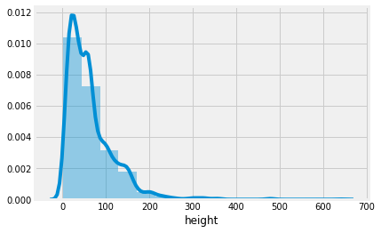

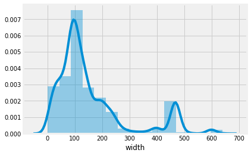

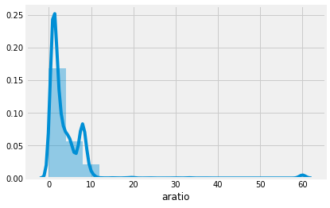

```python
feature_names = ["height", "width", "aratio"]
for i in feature_names:
    var = df[i].dropna()
    sns.distplot(var, hist=True,bins=15)
    plt.show()
```

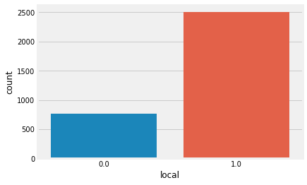

```python
df_local = df['local'].dropna()
sns.countplot(df_local)
plt.show()
```

## Missing value Treatment

```python
# Printing total numbers and percentage of missing data
def missing_val(df):
    # Total Number of missing vales
    print("Total Number of missing vales:", df.isnull().sum().sum())
    print("*"*20)

    # Number of missing vales
    number  = df.isnull().sum()
    print("Number of missing vales in each column")
    print(number[number >1])
    print("*"*20)

    # percent of missing vales
    percentages = round(df.isnull().sum() * 100/ len(df),3)
    print("percentage of missing vales in each column")
    print(percentages[percentages>0])
    print("*"*20)
    return

def replace_missing_val(df):
    # Replacing missing vales
    df.iloc[:,0:3]=df.iloc[:,0:3].fillna(df.iloc[:,0:3].dropna().median())

    df['local']=df['local'].fillna(df['local'].dropna().mode()[0])
    #Recheck for confirmation
    number  = df.isnull().sum()
    print(number[number >1])
    return
```

```python
missing_val(df)
replace_missing_val(df)
```

```
Total Number of missing vales: 2729
Number of missing vales in each column
height    903
width     901
aratio    910
local      15
dtype: int64
percentage of missing vales in each column
height    27.547
width     27.486
aratio    27.761
local      0.458
dtype: float64
Series([], dtype: int64)
```

## EDA

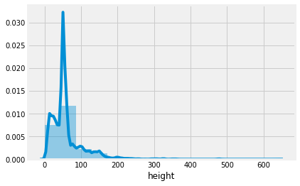

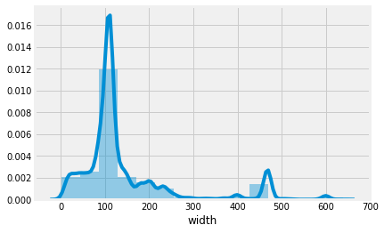

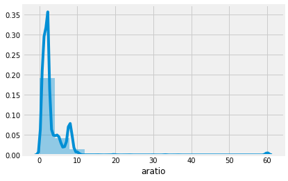

```python
for i in feature_names:
    var = df[i].dropna()
    sns.distplot(var, hist=True,bins=15)
    plt.show()
```

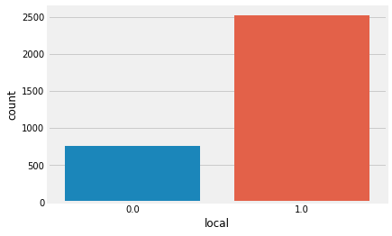

```python
df_local = df['local'].dropna()
sns.countplot(df_local)
plt.show()
```

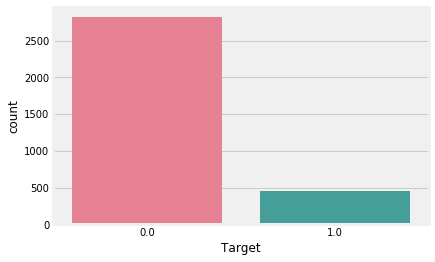

```python
sns.countplot(df['Target'],palette='husl')
plt.show()
```

```python
#sns.jointplot(x="height", y="width", data=df, kind="kde", color='b')
#plt.show()
```

```python
#sns.jointplot(x="height", y="aratio", data=df, kind="kde", color='b')
#plt.show()
```

```python
#sns.jointplot(x="width", y="aratio", data=df, kind="kde", color='b')
#plt.show()
```

```python
df.groupby('Target').count()
```

| Target | height | width | aratio | local | url_images_buttons | url_likesbooks_com | url_www_slake_com | url_hydrogeologist | url_oso | url_media | ... | caption_of | caption_home | caption_my | caption_your | caption_in | caption_bytes | caption_here | caption_click | caption_for | caption_you |
| --- | --- | --- | --- | --- | --- | --- | --- | --- | --- | --- | --- | --- | --- | --- | --- | --- | --- | --- | --- | --- | --- |
| 0.0 | 2820 | 2820 | 2820 | 2820 | 2820 | 2820 | 2820 | 2820 | 2820 | 2820 | ... | 2820 | 2820 | 2820 | 2820 | 2820 | 2820 | 2820 | 2820 | 2820 | 2820 |
| 1.0 | 458 | 458 | 458 | 458 | 458 | 458 | 458 | 458 | 458 | 458 | ... | 458 | 458 | 458 | 458 | 458 | 458 | 458 | 458 | 458 | 458 |

2 rows × 1558 columns

```
Mean:  60.41610738255034
Median:  51.0
Mode:  51.0
```

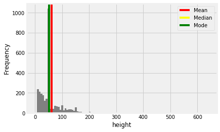

```
skew: 3.0588802275221854
kurt: 18.01828655487012
```

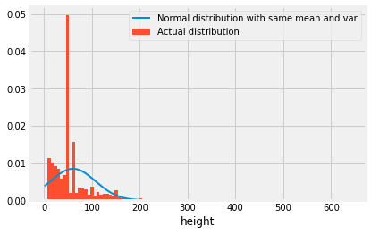

```
Mean:  142.89048200122025
Median:  110.0
Mode:  110.0
```

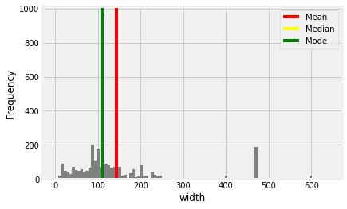

```
skew: 2.1313504602848905
kurt: 4.202549437549532
```

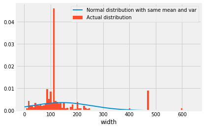

```
Mean:  3.4116461256864854
Median:  2.10655
Mode:  2.10655
```

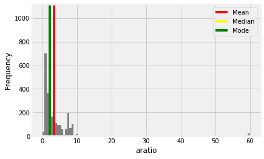

```
skew: 8.249746055509657
kurt: 84.44624314106223
```

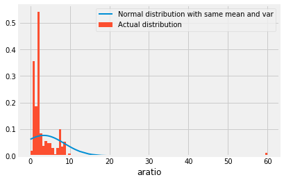

```python
for i in feature_names:
    var = df[i]
    mean   = var.mean()
    median = var.median()
    mode   = var.mode()
    print('Mean: ',mean,'\nMedian: ',median,'\nMode: ',mode[0])
    plt.hist(var,bins=100,color='grey')
    plt.axvline(mean,color='red',label='Mean')
    plt.axvline(median,color='yellow',label='Median')
    plt.axvline(mode[0],color='green',label='Mode')
    plt.xlabel(i)
    plt.ylabel('Frequency')
    plt.legend()
    plt.show()
    #minimum value
    df[i].min()
    #maximum value
    df[i].max()
    #Range
    df[i].max()-df[i].min()
    #variance
    df[i].var()
    #standard deviation
    sqrt(df[i].var())
    #50th percentile i.e median(q2)
    q2 = df[i].quantile(0.5)
    #75th percentile
    q3 = df[i].quantile(0.75)
    #25th percentile
    q1 = df[i].quantile(0.25)
    #interquartile range
    IQR = q3  - q1
    #skewness
    print("skew:",df[i].skew())
    #kutosis
    print("kurt:",df[i].kurt())

    #convert pandas DataFrame object to numpy array and sort
    h = np.asarray(df[i])
    h = sorted(h)

    #use the scipy stats module to fit a normal distirbution with same mean and standard deviation
    fit = stats.norm.pdf(h, np.mean(h), np.std(h))

    #plot both series on the histogram
    plt.plot(h,fit,'-',linewidth = 2,label="Normal distribution with same mean and var")
    plt.hist(h,normed=True,bins = 100,label="Actual distribution")
    plt.xlabel(i)
    plt.legend()
    plt.show()
    print('*'*30)
```

## Outlier Treatment

```python
def outlier_treat(df):

    for i in range(len(feature_names)):
        figure = plt.figure()
        ax = sns.boxplot(x=feature_names[i], data=df)

    # The diamond shaped dots outside the boxplot indicates the outliers
    for i in feature_names:
        q75, q25 = np.percentile(df[i], [75 ,25])

        #Calculate IQR
        iqr = q75 - q25

        #Calculate inner and outer fence
        minimum = q25 - (iqr*1.5)
        maximum = q75 + (iqr*1.5)

        #Replace with NA
        df.loc[df[i] < minimum,:i] = np.nan
        df.loc[df[i] > maximum,:i] = np.nan
    return
```

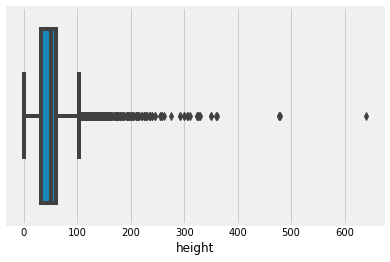

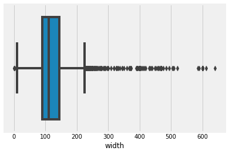

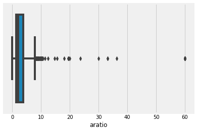

```python
outlier_treat(df)
```

```python
missing_val(df)
replace_missing_val(df)
```

```
Total Number of missing vales: 1782
Number of missing vales in each column
height    949
width     592
aratio    241
dtype: int64
percentage of missing vales in each column
height    28.951
width     18.060
aratio     7.352
dtype: float64
Series([], dtype: int64)
```

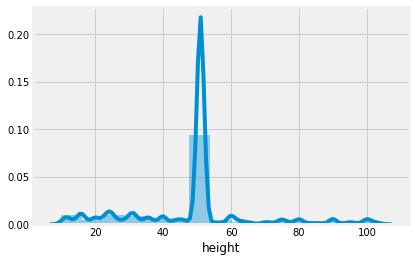

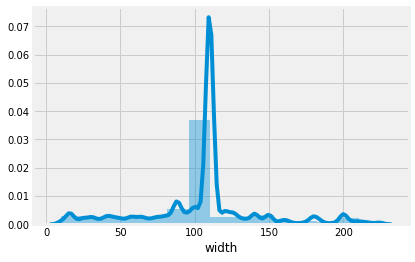

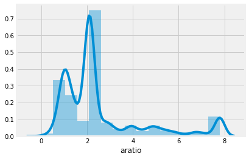

```python
for i in feature_names:
    var = df[i]
    sns.distplot(var, hist=True,bins=15)
    plt.show()
```

```python
df_con = df[['height','width','aratio','local']]
df_con.describe()
```

|  | height | width | aratio | local |
| --- | --- | --- | --- | --- |
| count | 3278.000000 | 3278.000000 | 3278.00000 | 3278.000000 |
| mean | 48.560403 | 105.896278 | 2.56235 | 0.768151 |
| std | 17.533503 | 39.112713 | 1.85388 | 0.422077 |
| min | 10.000000 | 10.000000 | 0.00150 | 0.000000 |
| 25% | 44.000000 | 94.000000 | 1.28255 | 1.000000 |
| 50% | 51.000000 | 110.000000 | 2.10655 | 1.000000 |
| 75% | 51.000000 | 110.000000 | 2.66660 | 1.000000 |
| max | 104.000000 | 225.000000 | 7.80000 | 1.000000 |

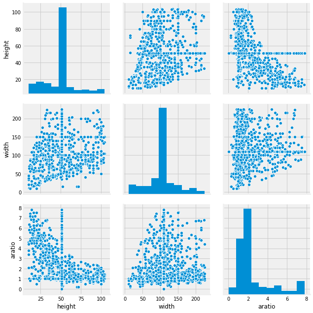

```python
sns.pairplot(df[['height', 'width', 'aratio']], size=3)
plt.show()
```

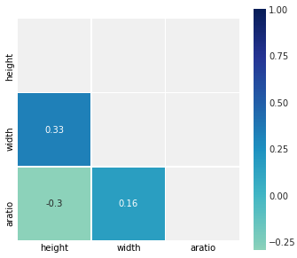

```python
corrmat = df[['height', 'width', 'aratio']].corr()
mask = np.zeros_like(corrmat)
mask[np.triu_indices_from(mask)] = True
plt.subplots(figsize=(5,5))
with sns.axes_style("white"):
    ax = sns.heatmap(corrmat, mask=mask, vmax=1, square=True, center=0, annot=True, linewidths=.5, cmap="YlGnBu")
```

## Split data -- features & labels

```python
X=df.iloc[:,:-1]
y=df.iloc[:,-1]
```

## Scaling the data

```python
scaled=StandardScaler()
X=scaled.fit_transform(X)
```

## Split data : Train & Test

```python
seed = 100
X_train,X_test,y_train,y_test=train_test_split(X, y, test_size = 0.30, random_state=seed, stratify = y)
# Show the results of the split
print("Training set has {} samples.".format(X_train.shape[0]))
print("Testing set has {} samples.".format(X_test.shape[0]))
```

```
Training set has 2294 samples.
Testing set has 984 samples.
```

```python
target_names = ["Nonad's", "ad's"]
```

```python
result_train = []
result_test = []
result_f1 = []
result_auc = []
result_cv = []
```

```python
def predict(clf):
    print(clf)
    print()
    clf.fit(X_train, y_train)
    print('Accuracy on train set: {:.3f}'.format(clf.score(X_train, y_train)))
    print()
    y_pred = clf.predict(X_test)
    print('Accuracy on test set: {:.3f}'.format(clf.score(X_test, y_test)))
    print()
    print('Logarithmic Loss \n', log_loss(y_test, y_pred, eps=1e-15, normalize=True, sample_weight=None, labels=None))
    print()
    print('Confusion Matrix \n', confusion_matrix(y_test, y_pred))
    print()
    print('Classification Report \n', classification_report(y_test, y_pred, target_names=target_names))
    print()
    f1 = f1_score(y_test, y_pred, labels=None, pos_label=1, average='binary', sample_weight=None)
    print('F1 Score \n', f1)
    print()
    print('Matthews correlation coefficient \n', matthews_corrcoef(y_test, y_pred))
    print()
    print('Mean Absolute Error \n', mean_absolute_error(y_test, y_pred, sample_weight=None, multioutput='uniform_average') )
    print()
    print('Mean Squared Error \n', mean_squared_error(y_test, y_pred, sample_weight=None, multioutput='uniform_average'))
    print()
    y_pred_proba = clf.predict_proba(X_test)[:,1]
    print('Area under curve = %0.3f' % (roc_auc_score(y_test,y_pred_proba)*100),"%")
    print()
    fpr, tpr, thresholds = roc_curve(y_test, y_pred_proba)
    plt.plot([0,1],[0,1],'k--')

    plt.plot(fpr,tpr, label='Area under curve = %0.3f' % roc_auc_score(y_test,y_pred_proba))
    plt.xlabel('False positive rate')
    plt.ylabel('True positive rate')
    plt.title('ROC curve')
    plt.legend(loc='best')
    plt.show()

    # 10-fold cross-validation
    #scores = cross_val_score(clf, X, y, cv=5, scoring='accuracy')
    cv = cross_val_score(clf, X, y, cv=10, scoring='accuracy').mean()
    print('Cross Validation Accuracy = ', cv)

    result_train.append(round((clf.score(X_train, y_train)*100), 3))
    result_test.append(round((clf.score(X_test, y_test)*100), 3))
    result_f1.append(round((f1*100), 3))
    result_auc.append(round((roc_auc_score(y_test,y_pred_proba)*100), 3))
    result_cv.append(round((cv*100), 3))
    return
```

## Dummy Classifier

```
DummyClassifier(constant=None, random_state=100, strategy='stratified')

Accuracy on train set: 0.764

Accuracy on test set: 0.772

Logarithmic Loss
 7.86257344408786

Confusion Matrix
 [[739 108]
 [116  21]]

Classification Report
               precision    recall  f1-score   support

     Nonad's       0.86      0.87      0.87       847
        ad's       0.16      0.15      0.16       137

   micro avg       0.77      0.77      0.77       984
   macro avg       0.51      0.51      0.51       984
weighted avg       0.77      0.77      0.77       984


F1 Score
 0.15789473684210528

Matthews correlation coefficient
 0.026438481746139646

Mean Absolute Error
 0.22764227642276422

Mean Squared Error
 0.22764227642276422

Area under curve = 51.289 %
```

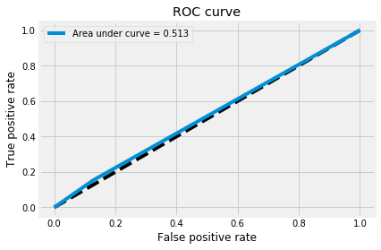

```
Cross Validation Accuracy =  0.7632729171328411
```

```python
dclf = DummyClassifier(strategy='stratified', random_state=seed, constant=None)
predict(dclf)
```

## Logistic Regression

```
LogisticRegression(C=1.0, class_weight=None, dual=False, fit_intercept=True,
          intercept_scaling=1, max_iter=100, multi_class='warn',
          n_jobs=None, penalty='l2', random_state=100, solver='warn',
          tol=0.0001, verbose=0, warm_start=False)

Accuracy on train set: 0.994

Accuracy on test set: 0.965

Logarithmic Loss
 1.193426007099438

Confusion Matrix
 [[831  16]
 [ 18 119]]

Classification Report
               precision    recall  f1-score   support

     Nonad's       0.98      0.98      0.98       847
        ad's       0.88      0.87      0.87       137

   micro avg       0.97      0.97      0.97       984
   macro avg       0.93      0.92      0.93       984
weighted avg       0.97      0.97      0.97       984


F1 Score
 0.8749999999999999

Matthews correlation coefficient
 0.8549852085916307

Mean Absolute Error
 0.034552845528455285

Mean Squared Error
 0.034552845528455285

Area under curve = 96.329 %
```

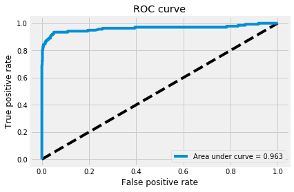

```
Cross Validation Accuracy =  0.9499533825613484
```

```python
logreg = LogisticRegression(random_state=seed)
predict(logreg)
```

## Naive Bayes Classifier

```
GaussianNB(priors=None, var_smoothing=1e-09)

Accuracy on train set: 0.813

Accuracy on test set: 0.795

Logarithmic Loss
 7.090424348482544

Confusion Matrix
 [[666 181]
 [ 21 116]]

Classification Report
               precision    recall  f1-score   support

     Nonad's       0.97      0.79      0.87       847
        ad's       0.39      0.85      0.53       137

   micro avg       0.79      0.79      0.79       984
   macro avg       0.68      0.82      0.70       984
weighted avg       0.89      0.79      0.82       984


F1 Score
 0.5345622119815668

Matthews correlation coefficient
 0.47737841825037386

Mean Absolute Error
 0.20528455284552846

Mean Squared Error
 0.20528455284552846

Area under curve = 81.651 %
```

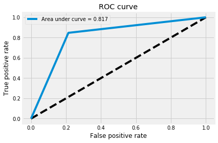

```
Cross Validation Accuracy =  0.7571744238084582
```

```python
nb = GaussianNB()
predict(nb)
```

## Decision Trees

```
DecisionTreeClassifier(class_weight=None, criterion='gini', max_depth=None,
            max_features=None, max_leaf_nodes=None,
            min_impurity_decrease=0.0, min_impurity_split=None,
            min_samples_leaf=1, min_samples_split=2,
            min_weight_fraction_leaf=0.0, presort=False, random_state=100,
            splitter='best')

Accuracy on train set: 0.998

Accuracy on test set: 0.972

Logarithmic Loss
 0.9828163986173896

Confusion Matrix
 [[840   7]
 [ 21 116]]

Classification Report
               precision    recall  f1-score   support

     Nonad's       0.98      0.99      0.98       847
        ad's       0.94      0.85      0.89       137

   micro avg       0.97      0.97      0.97       984
   macro avg       0.96      0.92      0.94       984
weighted avg       0.97      0.97      0.97       984


F1 Score
 0.8923076923076922

Matthews correlation coefficient
 0.8776583211090363

Mean Absolute Error
 0.028455284552845527

Mean Squared Error
 0.028455284552845527

Area under curve = 92.918 %
```

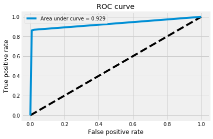

```
Cross Validation Accuracy =  0.9542179458491832
```

```python
dtcl = DecisionTreeClassifier(random_state=seed)
predict(dtcl)
```

## Support Vector Machine

```
SVC(C=1.0, cache_size=200, class_weight=None, coef0=0.0,
  decision_function_shape='ovr', degree=3, gamma='auto_deprecated',
  kernel='linear', max_iter=-1, probability=True, random_state=100,
  shrinking=True, tol=0.001, verbose=False)

Accuracy on train set: 0.994

Accuracy on test set: 0.946

Logarithmic Loss
 1.860343838674535

Confusion Matrix
 [[818  29]
 [ 24 113]]

Classification Report
               precision    recall  f1-score   support

     Nonad's       0.97      0.97      0.97       847
        ad's       0.80      0.82      0.81       137

   micro avg       0.95      0.95      0.95       984
   macro avg       0.88      0.90      0.89       984
weighted avg       0.95      0.95      0.95       984


F1 Score
 0.8100358422939068

Matthews correlation coefficient
 0.7788378712346875

Mean Absolute Error
 0.05386178861788618

Mean Squared Error
 0.05386178861788618

Area under curve = 95.482 %
```

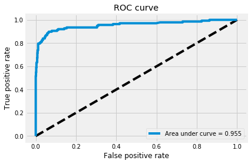

```
Cross Validation Accuracy =  0.9441551055418811
```

```python
svcl = SVC(kernel='linear',probability=True, random_state=seed)
predict(svcl)
```

## K-Nearest Neighbors

```
KNeighborsClassifier(algorithm='auto', leaf_size=30, metric='minkowski',
           metric_params=None, n_jobs=None, n_neighbors=5, p=2,
           weights='uniform')

Accuracy on train set: 0.964

Accuracy on test set: 0.936

Logarithmic Loss
 2.2113281614497198

Confusion Matrix
 [[842   5]
 [ 58  79]]

Classification Report
               precision    recall  f1-score   support

     Nonad's       0.94      0.99      0.96       847
        ad's       0.94      0.58      0.71       137

   micro avg       0.94      0.94      0.94       984
   macro avg       0.94      0.79      0.84       984
weighted avg       0.94      0.94      0.93       984


F1 Score
 0.7149321266968325

Matthews correlation coefficient
 0.7070966075371735

Mean Absolute Error
 0.06402439024390244

Mean Squared Error
 0.06402439024390244

Area under curve = 93.210 %
```

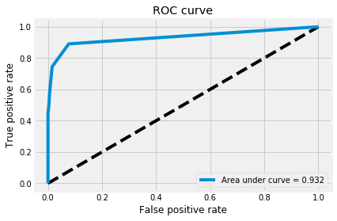

```
Cross Validation Accuracy =  0.9319357425225627
```

```python
knn = KNeighborsClassifier(n_neighbors=5, weights= 'uniform', algorithm='auto',
                                       leaf_size=30, p=2, metric='minkowski', metric_params=None,
                                       n_jobs=None)
predict(knn)
```

## RandomForest Model

```
RandomForestClassifier(bootstrap=True, class_weight=None, criterion='gini',
            max_depth=None, max_features='auto', max_leaf_nodes=None,
            min_impurity_decrease=0.0, min_impurity_split=None,
            min_samples_leaf=1, min_samples_split=2,
            min_weight_fraction_leaf=0.0, n_estimators=60, n_jobs=None,
            oob_score=False, random_state=100, verbose=0, warm_start=False)

Accuracy on train set: 0.998

Accuracy on test set: 0.979

Logarithmic Loss
 0.7371096580162455

Confusion Matrix
 [[845   2]
 [ 19 118]]

Classification Report
               precision    recall  f1-score   support

     Nonad's       0.98      1.00      0.99       847
        ad's       0.98      0.86      0.92       137

   micro avg       0.98      0.98      0.98       984
   macro avg       0.98      0.93      0.95       984
weighted avg       0.98      0.98      0.98       984


F1 Score
 0.9182879377431906

Matthews correlation coefficient
 0.908706615565806

Mean Absolute Error
 0.021341463414634148

Mean Squared Error
 0.021341463414634148

Area under curve = 97.469 %
```

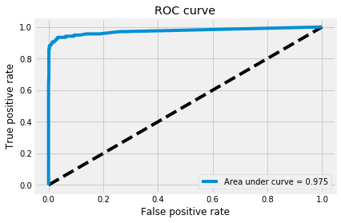

```
Cross Validation Accuracy =  0.9676372417393899
```

```python
rfcl = RandomForestClassifier(n_estimators=60, random_state=seed)
predict(rfcl)
```